# Prosper Loan Exploration

Samuel Wang

2017-01-05

# What borrower rate you need to pay when you wanna a loan from Prosper

This report explores a dataset containing LoanStatus and attributes for almost 114000 loan data in Prosper. I pick out 15 variables from the total 81 variables which I think are strongly relative to borrower. So firstly I deal with the original data into a subset and take a look at the subset as follows:

```
##  [1] "ListingCreationDate"              "CreditGrade"
##  [3] "Term"                             "LoanStatus"
##  [5] "BorrowerRate"                     "ProsperRating"
##  [7] "ProsperScore"                     "ListingCategory"
##  [9] "BorrowerState"                    "Occupation"
## [11] "CurrentDelinquencies"             "IncomeRange"
## [13] "TotalProsperLoans"                "TotalProsperPaymentdelinquencies"
## [15] "LoanOriginalAmount"
```

# Univariate Plots Section

The variable ‘TotalProsperPaymentdelinquencies’ represents the delinquencies a borrower made, which is equal to the difference between ‘TotalProsperPaymentsBilled’ and ‘OnTimeProsperPayments’, because I think this variable may represent a borrower’s credit, which is very important for applying a loan. Also I transform the value of ‘ListingCategory’ into the category which it means. And transform the value of ‘ListingCreationDate’ into date value.

Now let’s explore the data. Because I want to disscuss about the borrowers, so the first thing came up to my mind is how easily one person can borrow a loan from Prosper. Then you need know whether an application for a loan is accepted or not, Then I find a variable called LoanStatus.

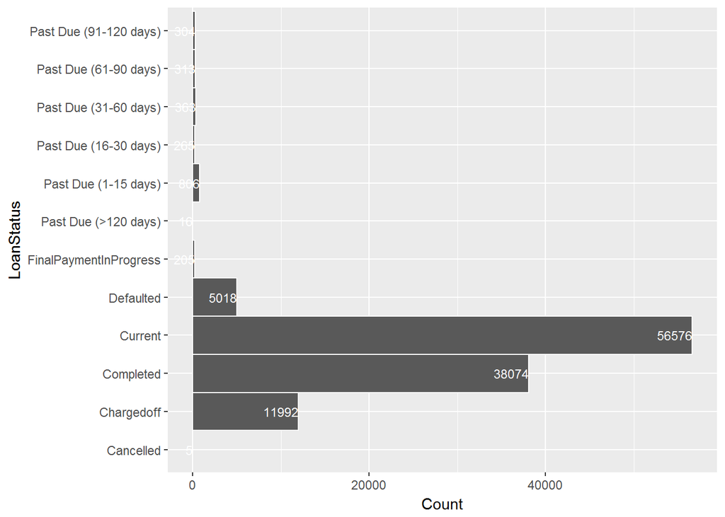

We can see that most of the loans are active but there still are some defaluted payments. But this variable stands for the status of a loan, I can’t find any evidence of how easily one can borrow a loan, so I choose the variable BorrowerRate, which is also very important for a borrower.

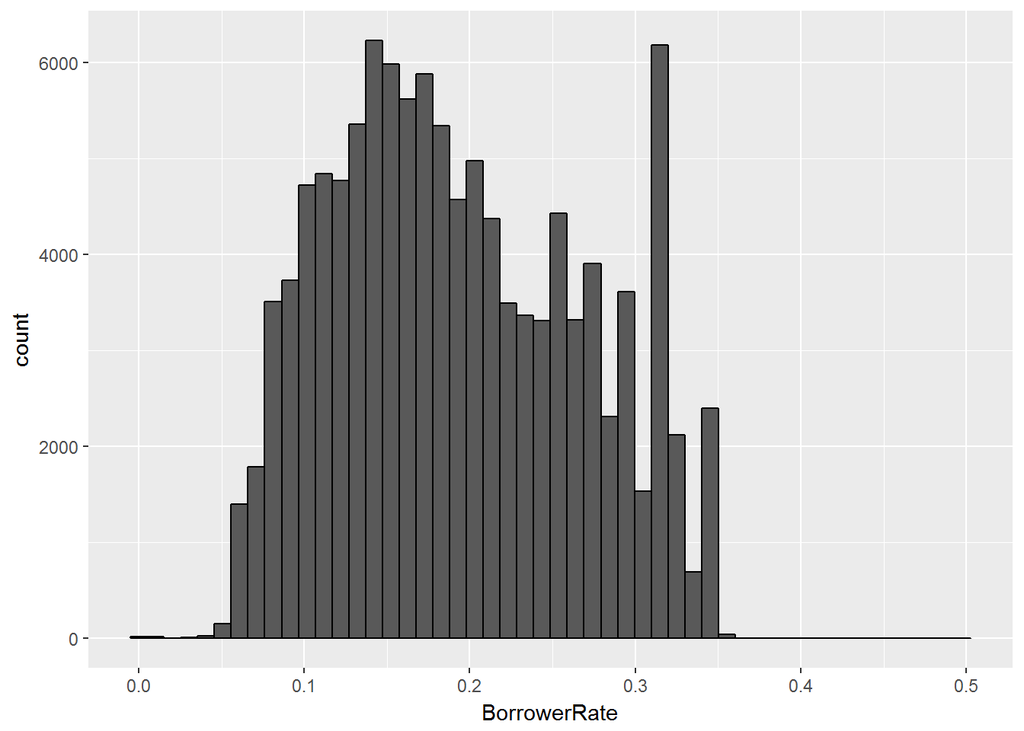

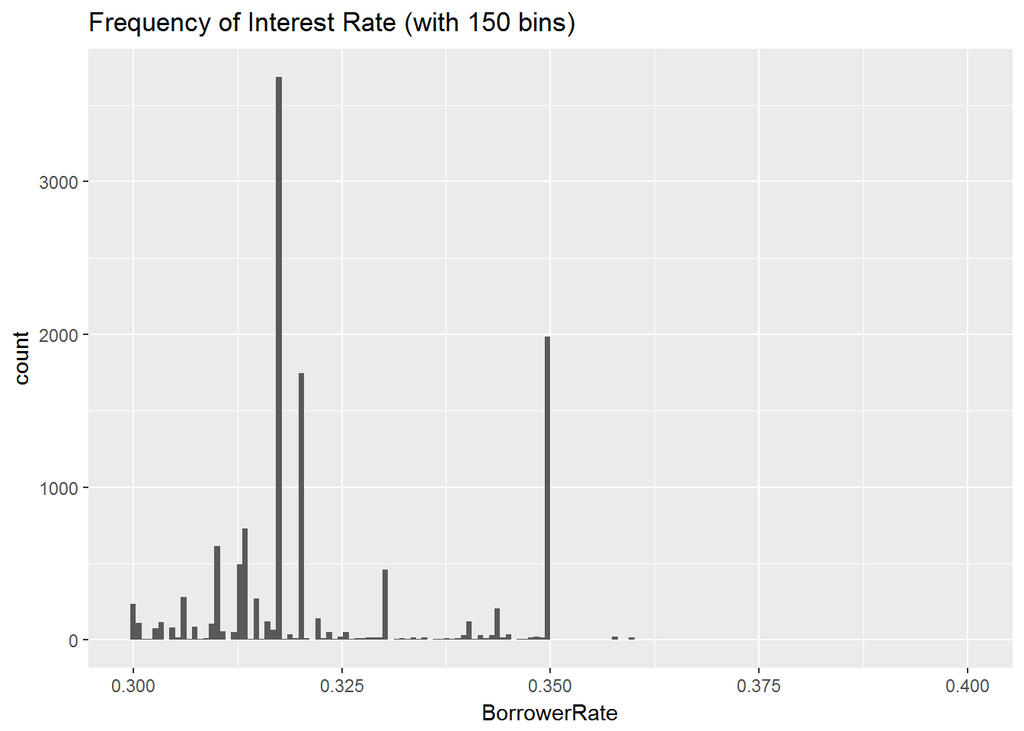

While taking the fact that this data is provided by Prosper into consideration, there must be few wrong data. Maybe there is a period when Prosper added thier fee of providing loans, then I draw a histogram to see the user counts at different years.

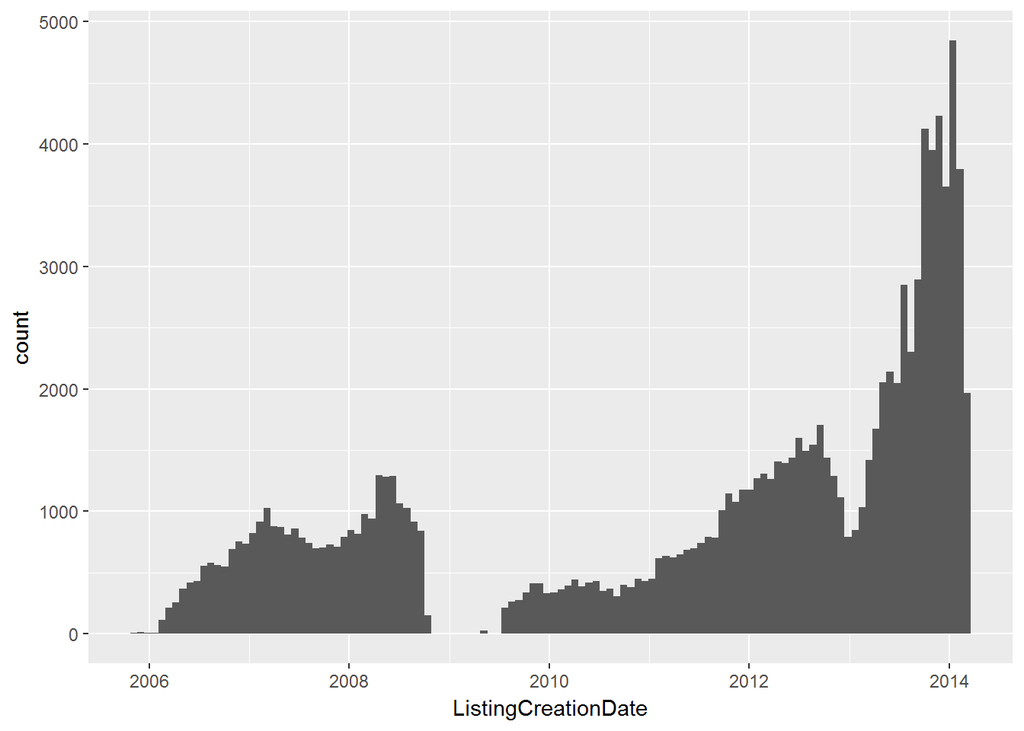

We could see that the loan records are distributed from the year 2006 to 2014, while there is a gap at 2009, from [Wiki](https://en.wikipedia.org/wiki/Prosper_Marketplace#2009_post_SEC_relaunch), we konw this ‘quite period’ is because a class action lawsuit was filed against Prosper in the Superior Court of California, County of San Francisco, California. Also I see that the records are much more in 2014 than the former years. With more and more people know Prosper, it becomes popular to invest and borrow a loan on Prosper.

Maybe there is a relationship between the month and the loan record, so I divide the variable ‘ListingCreationDate’ into year and month to see what will show.

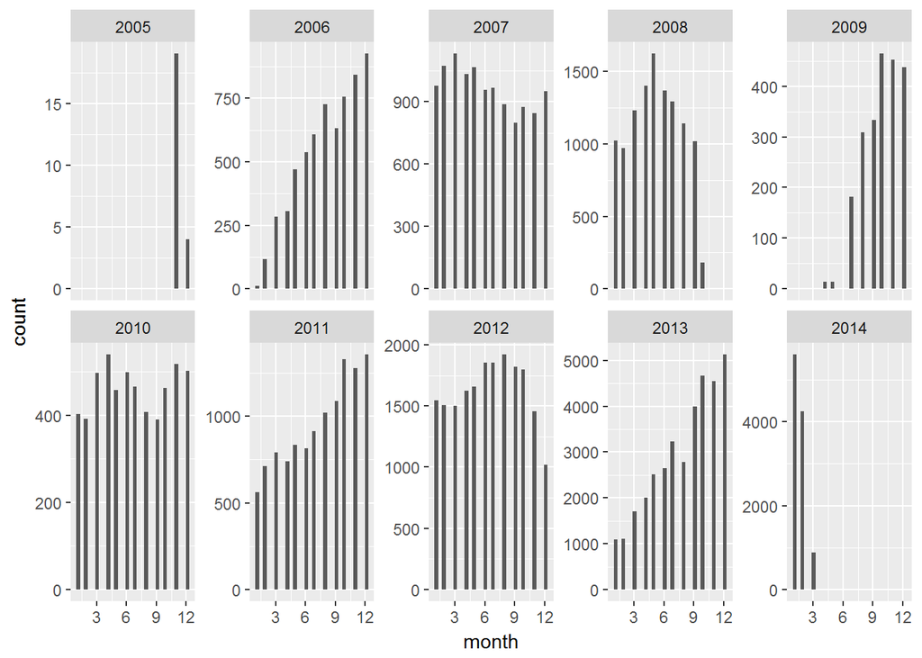

Well, it seems there is no clear evidence.Now we know some information about the loan creation date, and it may influence the borrowerrate. I need analysis more variables which may influence the borrowerRate, and in fact I have zoomed in the variables which I think will have impact on borrowerRate, what I should do now is analysis one by one. Well, the next is the length of the loan expressed in months.

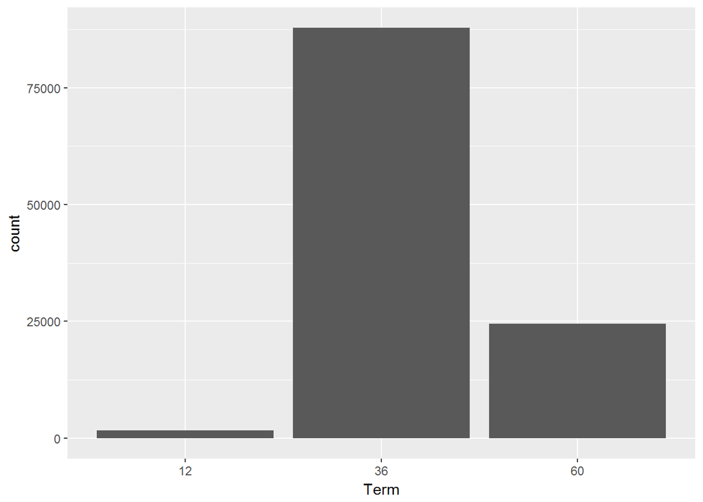

From the above histogram, we can find that Prosper provides mostly 36-months loans, then 60-months, 12-months at least. From the count of loans and rule of thumb, maybe these 12-months loans is those high borrowerRate loans, which we can discuss in the next part. Let’s see how custom risk score distribute, which was created by Prosper in order to assess risk. The score ranges from 1-11, with 11 being the best, or lowest, risk score.

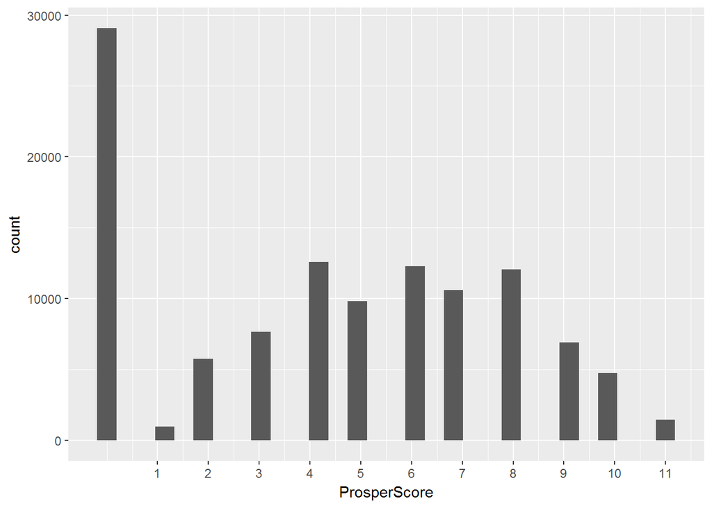

We can see that except for the missing values, borrowers’ score are approximately normally distributed. Most of the borrowers have score ranging from 4 to 8. How about the ListingCategory:

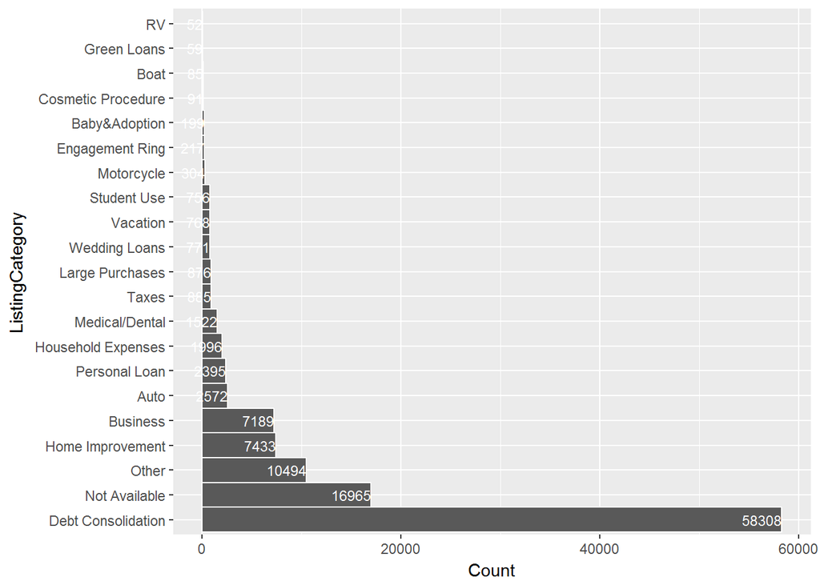

From the above figure, we could tell that most loans on Prosper are for Debt Consolidation. Excluding the Not Available and Other purposes, most of the loans go into Home Improvement, Business. While categories like entaimment things such as RV, Boat, Motorcycle, Vacation only accupate a small portion of the loan. Therefore, I conclude that most the people borrow money for necessary needs. Then how about the state:

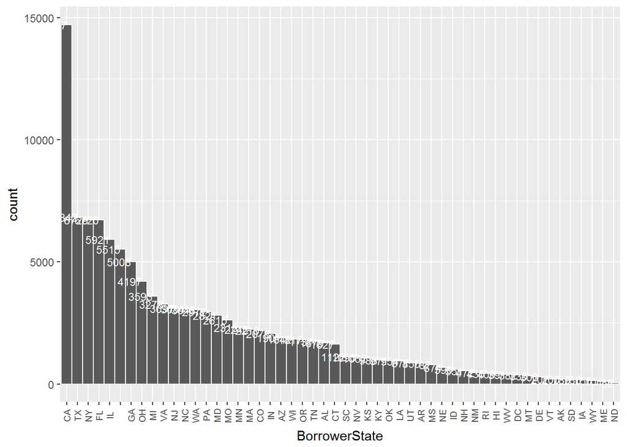

As we can see from this histgrom, CA, TX, NY, Fl and IL have the most borrowers. It seems that these states are the most populous and economically areas as well. How about the occupation of the borrowers:

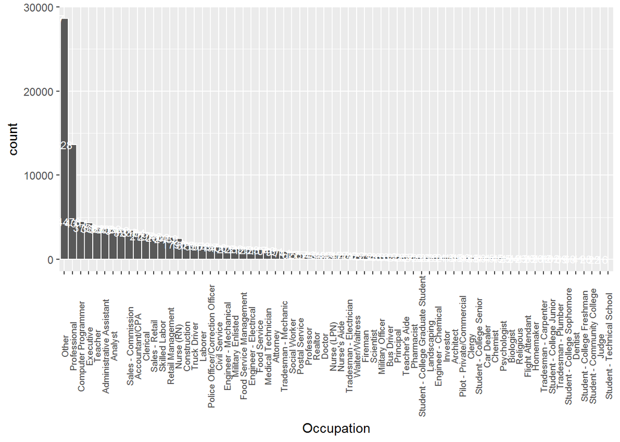

There are so many borrowers who hadn’t provided their occupation, ignoring this, Professional, computer programmer, Executive etc. borrow a loan most, and the tail show that few student borrow a loan, which meets the ListingCategory. So how about the borrowers’ income:

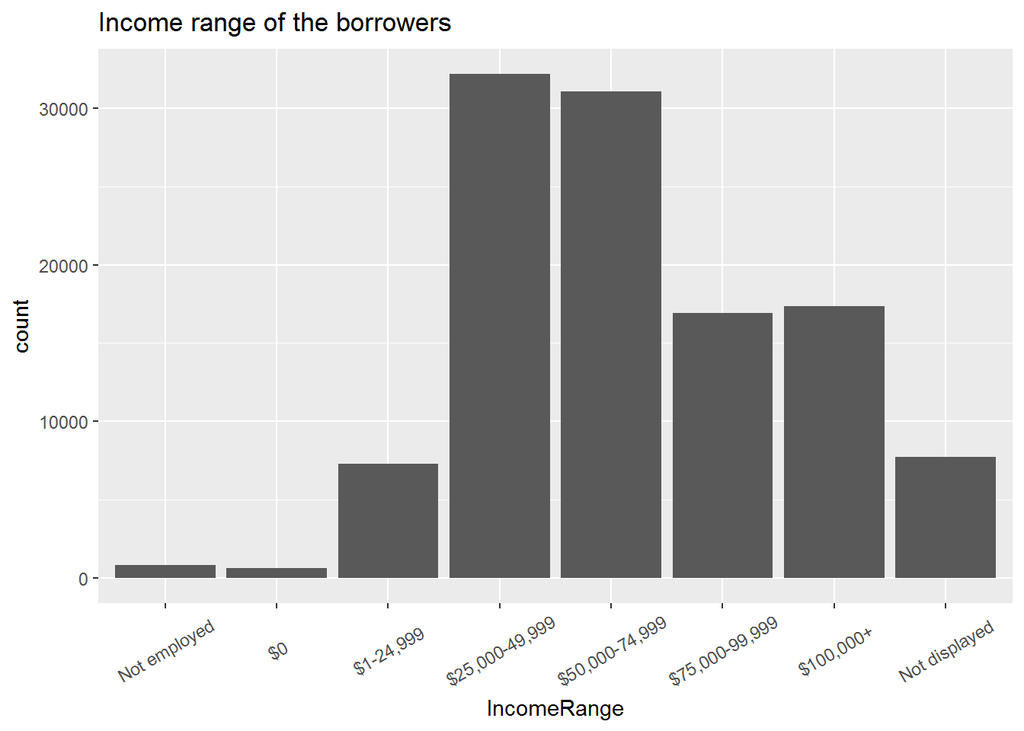

Most of the people using Prosper have an income between $25000 and $75000. The original amount of a loan can definitely impact the borrower rate, so let’s study it.

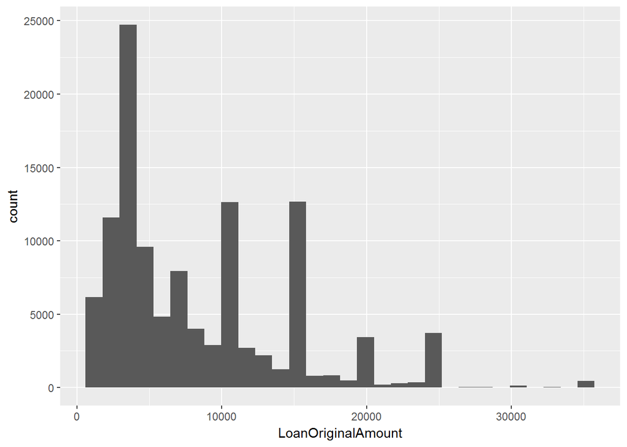

It looks like a long tail data, so for better understand the distribution of the LoanOriginalAmount, I transformed this distribution on a log scale.

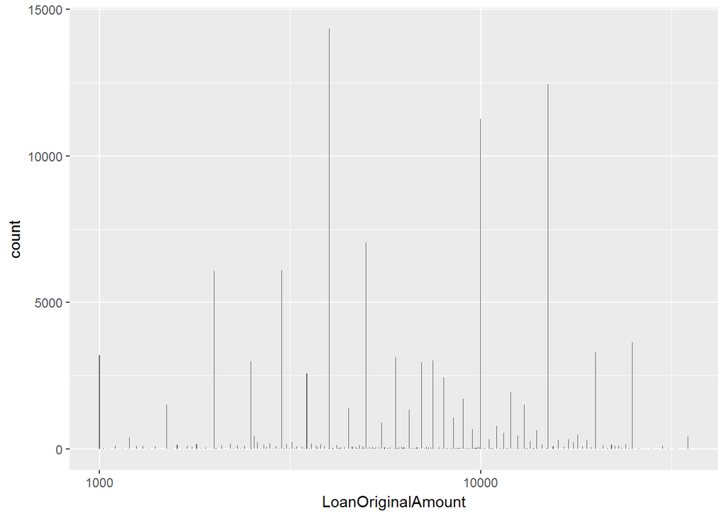

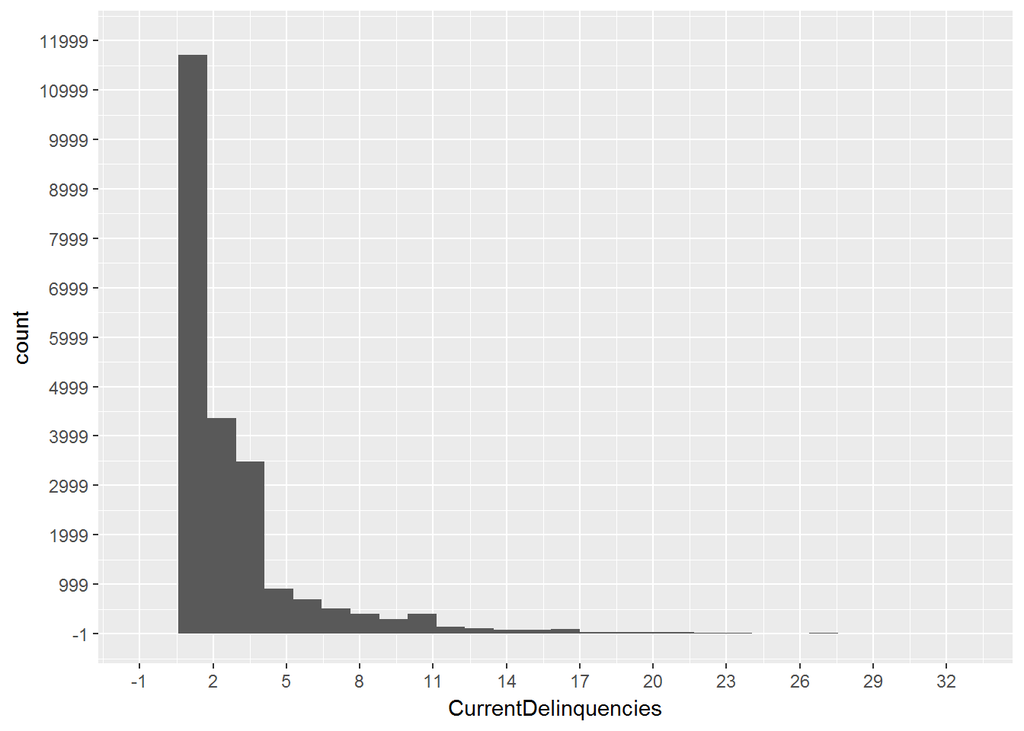

A large part of people haven’t had a delinquencies, while there are serval borrowers have had one or two times delinqunencies, also very few people had more than 10 times delinquencies, I’m curious about how can they get further loans with such a bad credit, maybe their further loans should provide higher borrower rate.

# Univariate Analysis

### What is the structure of your dataset?

There are 113937 loan records with 81 variables in the dataset, some are numeric and some are factor. While I choose 15 variables which are all relative to the borrowers from the whole set.

### What is/are the main feature(s) of interest in your dataset?

I care about what kinds of people will borrow a loan and what characters can improve the deal of loan. So the main feature in this data set is borrowerrate, which a borrower cares most. I want to find out which variables have impact on it.

### What other features in the dataset do you think will help support your investigation into your feature(s) of interest?

I think that ProsperRating and CreditGrade have big impacts on BorrowerRate, since lending money to lower rating borrower may have higher risks. Moreover, IncomeRange, Term, Occapution, CurrentDelinquencies and LoanOriginalAmount may also help me investigate the BorrowerRate.

### Did you create any new variables from existing variables in the dataset?

Yes, The variable ‘TotalProsperPaymentdelinquencies’ represents the delinquencies a borrower made, which is equal to the difference between ‘TotalProsperPaymentsBilled’ and ‘OnTimeProsperPayments’, because I think this variable may represent a borrower’s credit, which is very important for applying a loan. Also I transform the value of ‘ListingCategory’ into the category which it means. And transform the value of ‘ListingCreationDate’ into date value.

### Of the features you investigated, were there any unusual distributions? Did you perform any operations on the data to tidy, adjust, or change the form of the data? If so, why did you do this?

# Bivariate Plots Section

Since I have explored the univarite data, the next step is Bivariate section. BUT first, I’m very curious about the relationship between CreditGrade and ProsperRating, let’s check it.

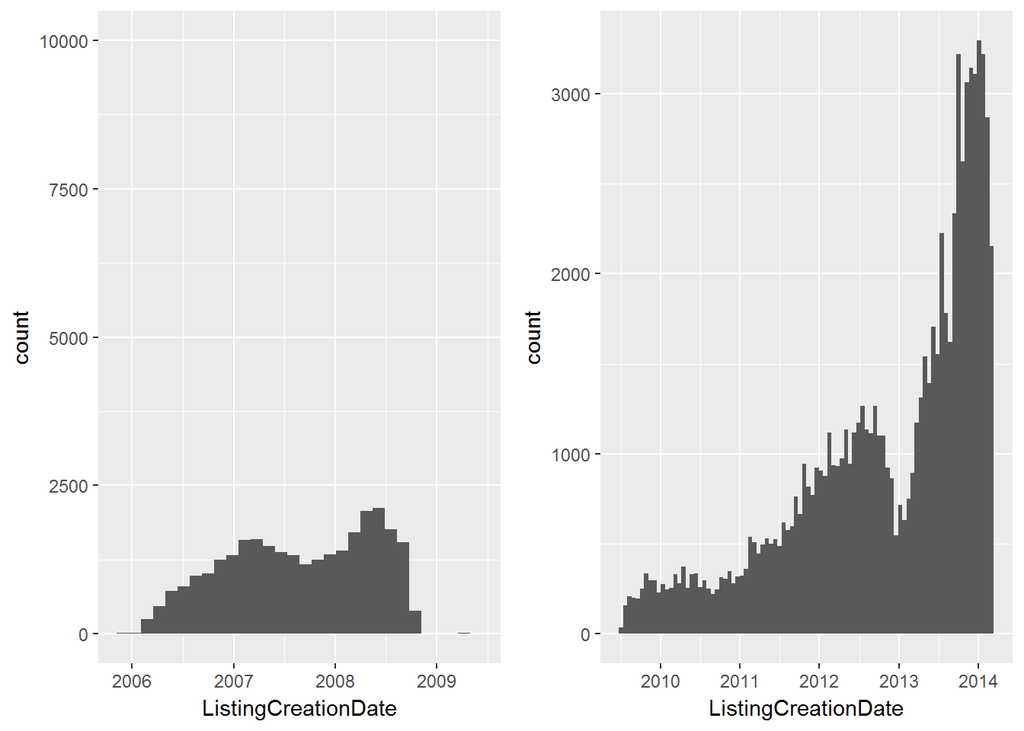

There two variables presents the credit of a person, after the lawsuit, Prosper added the ProsperRating to stand for borrower’s credit. So I combined these two into CreditRating.

With the selected variables, let’s see the correlation matrix.

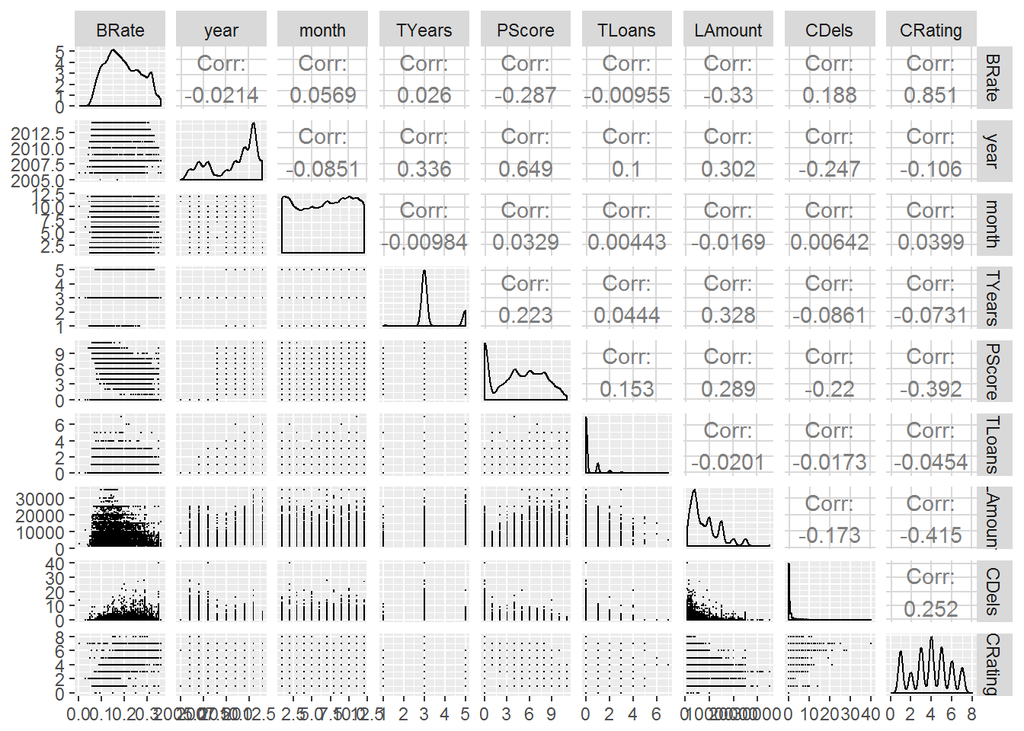

The correlation matrix is showed above, the labels in the matrix is mapped like this: BRate->BorrowerRate, TYears->TermYears, PScore->ProsperScore, TLoans->TotalProsperLoans, LAmount->LoanOriginalAmount, CDelis->CurrentDelinquencies, CRating->CreditRating, I also tranformed Term to TermYears, but there is no significant relevance between Term and borrowerRate, and this is out of my mind. From the correlation matrix, we see that CreditRating has the strongest relationship with BorrowerRate, and OriginalAmount next. Though the correlation between BorrowerRate and ProsperScore is less than 0.3, I still wanted to draw a boxplot to see it in detail.

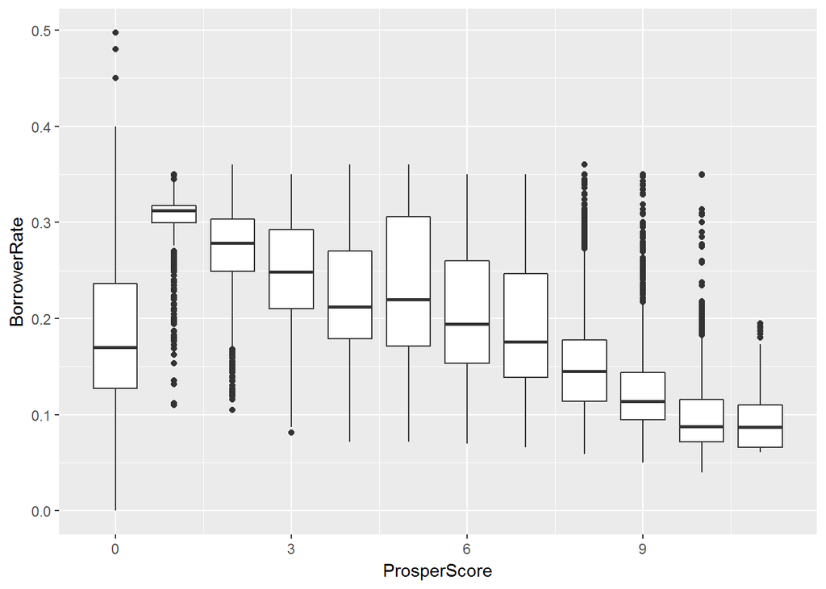

From the boxplot above, we saw that without the outliers, there is a trendency that higher scores in Prosper recieve a lower borrower rate. So I removed the data whose ProsperScore is 0 and checked the corretionship.

```
##
##  Pearson's product-moment correlation
##
## data:  BorrowerRate and ProsperScore
## t = -237.46, df = 83395, p-value < 2.2e-16
## alternative hypothesis: true correlation is not equal to 0
## 95 percent confidence interval:
##  -0.6391634 -0.6310649
## sample estimates:
##        cor
## -0.6351316
```

We saw the cor is equal to -0.6351316, it’s strong relevated. Actually I also wanted to remove the outliers in each group, as the boxplot showed before, scores like 1, 2, 8, 9, 10 have several outliers, I should have removed those away, but I don’t know how.(to the reviewer: can you help me, please?). Then I’m curious about the relationship between month and term, year and Term.

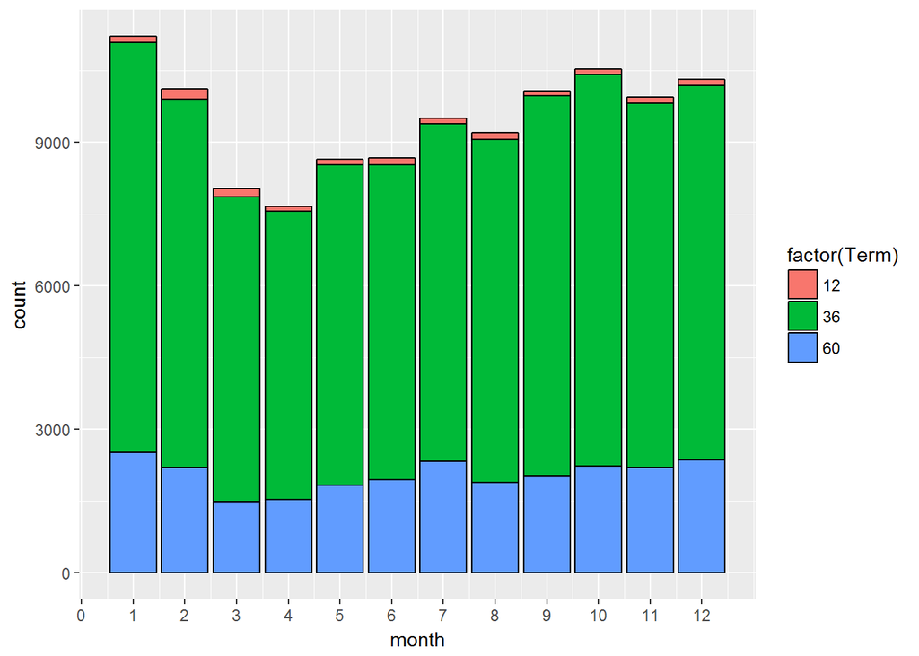

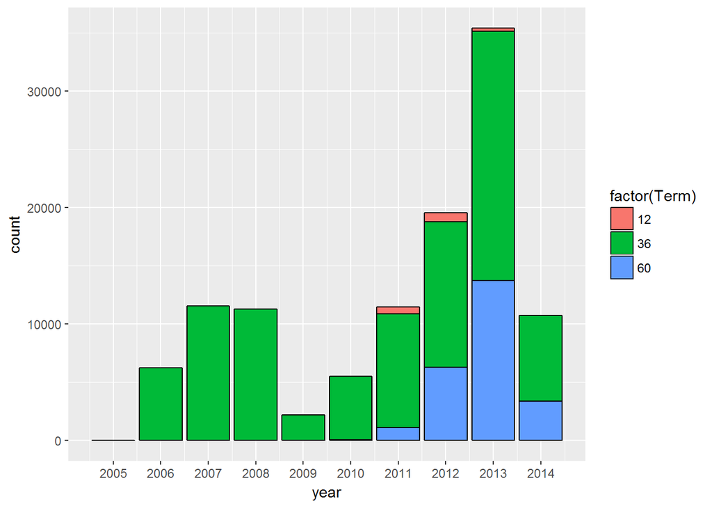

The most part of loans are 36-month, January has the contributes the most loans while March and April has the least loans. Maybe Within the Christmas and New Year holiday, people spend too much in shopping and transportation, then they need loans in January. In my opinion, there will be strong relationship between CreditRating and ProsperScore, so let’s check it.

```
##
##  Pearson's product-moment correlation
##
## data:  CreditRating and ProsperScore
## t = -262.12, df = 83395, p-value < 2.2e-16
## alternative hypothesis: true correlation is not equal to 0
## 95 percent confidence interval:
##  -0.6758094 -0.6683670
## sample estimates:
##        cor
## -0.6721052
```

The cor is -0.6721052, more stronger than BorrowerRate and ProsperScore. How about the relationship between the LoanOriginalAmount and income range?

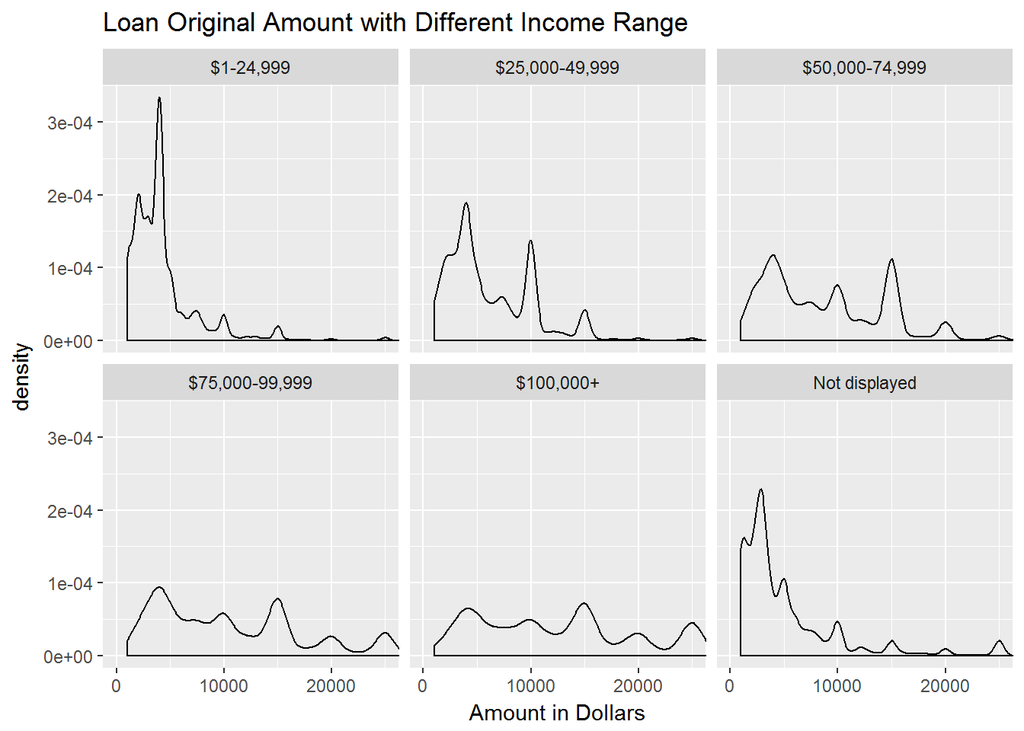

I classified $0, Not employed and Not displyed into one class for the reason that they didn’t provide income information, and I found that with lower income, the loans trends to lower than 10000 dollars, while with higher income, for example, $75,000-99,999 and $100,000+, the density above 20000 is higher.

```
##
##  Pearson's product-moment correlation
##
## data:  BorrowerRate and LoanOriginalAmount
## t = -113.61, df = 109620, p-value < 2.2e-16
## alternative hypothesis: true correlation is not equal to 0
## 95 percent confidence interval:
##  -0.3298425 -0.3192504
## sample estimates:
##        cor
## -0.3245567
```

# Bivariate Analysis

### Talk about some of the relationships you observed in this part of the investigation. How did the feature(s) of interest vary with other features in the dataset?

I first found that BorrowerRate is related to the ProsperScore. Without the outliers, borrowers need to afford a higher rate with a lower ProsperScore.

### Did you observe any interesting relationships between the other features (not the main feature(s) of interest)?

As I mentioned before, the main feature in my analysis is BorrowerRate, besides it, I also observed other features like month and Term, year and Term, ProsperScore and CreditRating, IncomeRange and LoanOriginalAmount.

### What was the strongest relationship you found?

From the correlation matrix, the strongest relationship was BorrowerRate and CreditRating which I mixed from CreditGrade and ProsperRating.

# Multivariate Plots Section

As I have metioned on the Bivariate part, 36-month term loans are from the beginning to the end, also the numbers are the most, so I controlled this variable to be 36-month, then I plotted the Borrower rate by list creation date, adding some colors using the ProsperScore.

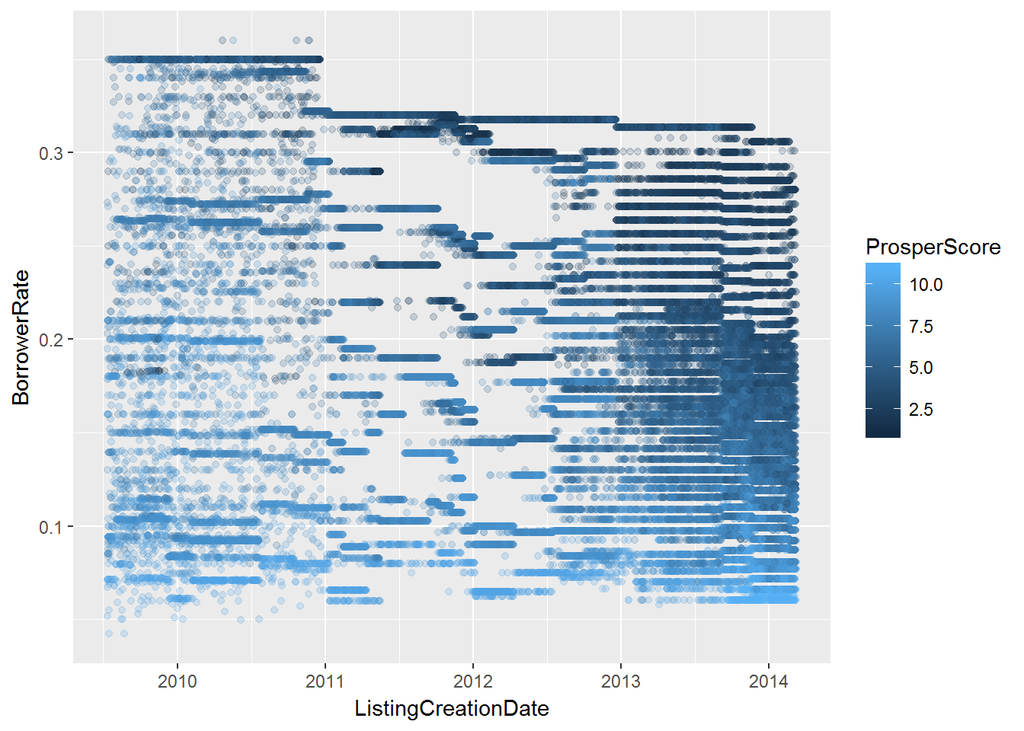

Next I wanted to build a linear model. As I analyzed before, CreditRating, ProsperScore, LoanOriginalAmount and Term have a clear relationship with BorrowerRate, so I built a four linear model like as follows.

```
##
## Calls:
## m1: lm(formula = BorrowerRate ~ CreditRating, data = subset(prosperLoan,
##     ProsperScore > 0 & LoanOriginalAmount > 0))
## m2: lm(formula = BorrowerRate ~ CreditRating + ProsperScore, data = subset(prosperLoan,
##     ProsperScore > 0 & LoanOriginalAmount > 0))
## m3: lm(formula = BorrowerRate ~ CreditRating + ProsperScore + LoanOriginalAmount,
##     data = subset(prosperLoan, ProsperScore > 0 & LoanOriginalAmount >
##         0))
## m4: lm(formula = BorrowerRate ~ CreditRating + ProsperScore + LoanOriginalAmount +
##     Term, data = subset(prosperLoan, ProsperScore > 0 & LoanOriginalAmount >
##     0))
##
## ==================================================================
##                          m1         m2         m3         m4
## ------------------------------------------------------------------
##   (Intercept)          0.051***   0.062***   0.069***   0.031***
##                       (0.000)    (0.001)    (0.001)    (0.001)
##   CreditRating         0.038***   0.037***   0.036***   0.036***
##                       (0.000)    (0.000)    (0.000)    (0.000)
##   ProsperScore                   -0.001***  -0.001***  -0.001***
##                                  (0.000)    (0.000)    (0.000)
##   LoanOriginalAmount                        -0.000***  -0.000***
##                                             (0.000)    (0.000)
##   Term: 36/12                                           0.039***
##                                                        (0.001)
##   Term: 60/12                                           0.050***
##                                                        (0.001)
## ------------------------------------------------------------------
##   R-squared                 0.9        0.9        0.9        0.9
##   adj. R-squared            0.9        0.9        0.9        0.9
##   sigma                     0.0        0.0        0.0        0.0
##   F                    514621.4   259063.3   174160.5   113611.6
##   p                         0.0        0.0        0.0        0.0
##   Log-likelihood       182759.9   183007.7   183313.4   186384.4
##   Deviance                 66.9       66.5       66.0       61.4
##   AIC                 -365513.8  -366007.4  -366616.9  -372754.7
##   BIC                 -365485.8  -365970.0  -366570.1  -372689.3
##   N                     84853      84853      84853      84853
## ==================================================================
```

# Multivariate Analysis

### Talk about some of the relationships you observed in this part of the investigation. Were there features that strengthened each other in terms of looking at your feature(s) of interest?

From the linear model, I found that CreditRating which is mixed by CreditGrade and ProsperRating and the length of loans are good indicators for the borrower interest of loans.

### Were there any interesting or surprising interactions between features?

Actually there is a thing surprising me a lot that in linear model, the ratio of LoanOriginalAmount is equal to 0. As I checked before, the correlationship between BorrowerRate and LoanOriginalAmount is -0.3245567, there should be some contribution from Loan Original amount.

### OPTIONAL: Did you create any models with your dataset? Discuss the strengths and limitations of your model.

Yes, I built a four linear model with features CreditRating, ProsperScore, LoanOriginalAmount and Term to predict the borrower rate of a loan. And from the result, adj. R-squared is equal to 0.9, which means this model can be used to predict the outcome correctly. While the limitations is that seems variable LoanOriginalAmount doesn’t contribute the prediction.

# Final Plots and Summary

### Plot One

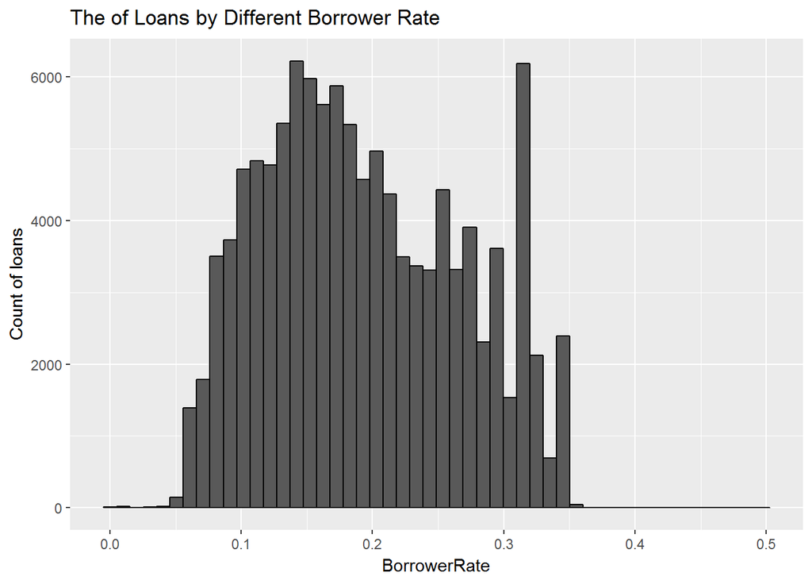

### Description One

```
##    Min. 1st Qu.  Median    Mean 3rd Qu.    Max.
##  0.0000  0.1340  0.1840  0.1928  0.2500  0.4975
```

From the above histogram of BorrowerRate, we saw that borrowers’ rate approximated follows a normal distrution besides serval outliers around 0.32. The mean is 0.1928, which means one person should take almost 20% interest rate by year into consideration to borrow a loan from Prosper.

### Plot Two

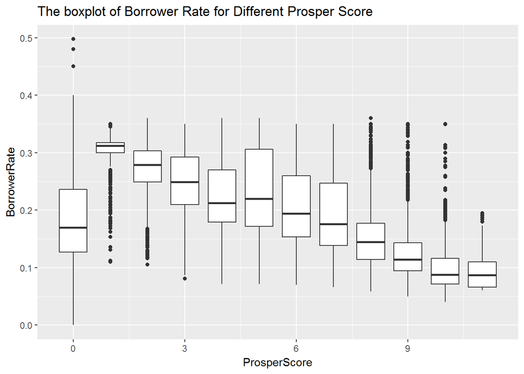

### Description Two

There is a trendency that higher scores in Prosper recieve a lower borrower rate. By checking the correaltion to Borrowe rate without those records whose prosper score equal to 0, the cor value is -0.6351316, it proved my assumpation.

### Plot Three

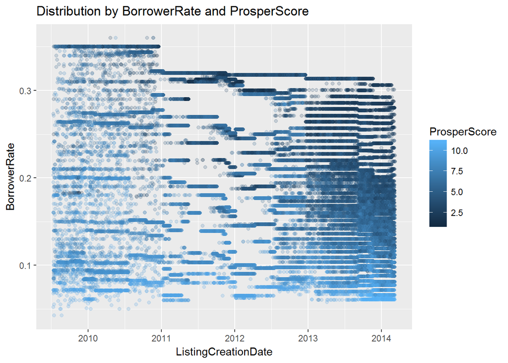

# Reflection

At the beginning, I didn’t know what to dig from the data set. I used function summay to see the whole picture of the dataset, the Prosper loan data set has 113,937 transaction record with 81 variables. I wanted to reduce the variables, so I need to find a topic which I was interested in. Since this is a dataset about renting and borrowing loans, the most important part should be borrower rate and loan yield, I focused on borrower rate. Then everything became clear. I picked out several variables may related to the borrower rate, then analyzed them one by one, I transformed some variables from the subset, I mixed some variables as well. When I’ve done with analyzing one certain variable, I began to find relationship between two then there and more. At last, I found out four variables which have impact on borrower rate clearly, so I made a four linear model using this four features to predict the borrower rate.

For future work, I would like to build more complex models with the knowledge of machine learning so that the prediction could be more accurate.